# **Caracterización del Ozono Troposférico (O₃) en el Área Metropolitana del Valle de México (AMVM)**

El ozono ($O₃$) es una especie alotrópica triatómica del oxígeno, constituida por tres átomos de dicho elemento. Su influencia ambiental y sanitaria es dual y depende de su distribución altitudinal en la atmósfera. En la estratosfera —donde forma la denominada “capa de ozono”— actúa como un filtro natural de la radiación ultravioleta (UV), atenuando la fracción biológicamente activa de las longitudes de onda UV-B. En contraste, en la troposfera (nivel superficial), el ozono se clasifica como un contaminante secundario de elevada reactividad y potencial oxidativo. A diferencia de los contaminantes primarios, el ozono troposférico no se libera directamente a la atmósfera, sino que se forma in situ a través de procesos fotoquímicos. Es un constituyente clave del smog fotoquímico, producto de la interacción entre precursores —principalmente óxidos de nitrógeno (NOₓ) y compuestos orgánicos volátiles (COV)— bajo condiciones de radiación solar intensa. Dichos precursores derivan, de manera predominante, de la combustión de hidrocarburos fósiles en el transporte motorizado, las plantas termoeléctricas y diversas actividades industriales.

La reacción global de formación del ozono troposférico puede expresarse como:

$COV + NOₓ + hν (radiación solar) → O₃$

donde $hν$ representa la energía fotónica necesaria para iniciar la fotólisis de NO₂ y subsecuentes reacciones radicalarias que conducen a la generación de ozono.

**Efectos sobre la salud humana**

La inhalación de ozono resulta altamente perjudicial debido a su potente acción oxidante, que provoca inflamación y daño celular en el sistema respiratorio. Sus efectos pueden manifestarse tanto a corto como a largo plazo.

- **Corto plazo:** Irritación de vías respiratorias (tos, dolor torácico, disnea), reducción de la función pulmonar y exacerbación de asma, bronquitis o enfisema.
- **Largo Plazo:** Daño pulmonar irreversible, incremento del riesgo de enfermedades crónicas (asma infantil, patologías cardiovasculares) e inflamación sistémica con posible relación a enfermedades neurodegenerativas.

**Monitoreo de ozono en el Área Metropolitana del Valle de México (AMVM)**

En el Área Metropolitana del Valle de México (AMVM) se han implementado, desde hace varias décadas, sistemas de vigilancia sistemática de la calidad del aire con el objetivo de evaluar y mitigar los problemas derivados de la contaminación atmosférica. Las primeras mediciones de calidad del aire en la región se iniciaron en la década de 1960, con un alcance limitado y centradas principalmente en el dióxido de azufre $(SO₂)$ y las partículas suspendidas totales $(PST)$. Durante la década de 1970 se estableció una red manual de estaciones de monitoreo. Sin embargo, la consolidación de un sistema automático, continuo y más integral —capaz de medir múltiples contaminantes, incluido el ozono $(O₃)$ — se concretó a finales de la década de 1980, marcando el inicio de la Red Automática de Monitoreo Atmosférico.

En la actualidad, el Sistema de Monitoreo Atmosférico de la Ciudad de México (SIMAT), adscrito a la Secretaría del Medio Ambiente de la Ciudad de México, opera una red de 48 estaciones distribuidas estratégicamente en el AMVM para ofrecer una caracterización espacial y temporal detallada de la calidad del aire. La determinación de la concentración de ozono en estas estaciones se realiza de manera automática, empleando predominantemente el método de absorción de radiación ultravioleta (UV). Este procedimiento consiste en aspirar una muestra de aire ambiente y exponerla a una fuente de luz UV; el ozono presente en la muestra absorbe una fracción específica de esa radiación, y la magnitud de la absorción es directamente proporcional a la concentración de ozono en el aire (Ley de Beer-Lambert).

**Índices de calidad del aire y riesgo asociado al ozono**

El riesgo sanitario derivado de la exposición al ozono en el AMVM se evalúa mediante el Índice AIRE Y SALUD, instrumento oficial que clasifica los niveles de riesgo en función de las concentraciones atmosféricas de ozono, expresadas en partes por millón (ppm), partes por billón (ppb) o microgramos por metro cúbico (µg/m³).

Este índice está regulado por la Norma Oficial Mexicana NOM-172-SEMARNAT-2023, la cual establece los criterios para la comunicación del riesgo a la población. En el caso del ozono, la clasificación contempla cinco rangos o “bandas” de calidad del aire, cada uno asociado a un nivel de riesgo y a recomendaciones específicas para la población. Dichos valores se determinan tanto a partir de la concentración promedio en intervalos de una hora como de la concentración promedio móvil en ocho horas, en concordancia con las directrices de la Organización Mundial de la Salud (OMS).

| Calidad del aire | Nivel de riesgo | Intervalo de O₃ promedio de 1 hora (ppm) | Intervalo de O₃ promedio móvil de 8 horas (ppm) |
| --- | --- | --- | --- |
| Buena (Verde) | Bajo | ≤ 0.051 | ≤ 0.051 |
| Aceptable (Amarillo) | Moderado | >0.051 y ≤0.095 | >0.051 y ≤0.070 |
| Mala (Naranja) | Alto | >0.095 y ≤0.135 | >0.070 y ≤0.092 |
| Muy Mala (Rojo) | Muy Alto | >0.135 y ≤0.175 | >0.092 y ≤0.114 |
| Extremadamente Mala (Morado) | Extremadamente Alto | >0.175 | > 0.114 |

El cálculo del índice de calidad del aire para ozono se fundamenta en promedios temporales que permiten evaluar tanto exposiciones agudas como crónicas, diferenciando así los efectos adversos sobre la salud.

- Promedio horario (1 hora): Este indicador es esencial para identificar los picos instantáneos de concentración de ozono. El uso del promedio horario posibilita una respuesta inmediata, facilitando la activación de protocolos de alerta y comunicación de riesgo a la población, dado que refleja de manera directa la situación actual.
- Promedio móvil de ocho horas: Este valor permite estimar la exposición acumulada y prolongada al ozono. El promedio móvil de ocho horas se actualiza cada hora, calculándose a partir de la media de la hora en curso y las siete anteriores. Esta metodología ofrece un panorama más representativo del riesgo para la salud a mediano y largo plazo.

**Distribución espacial y diferencias entre estaciones**

| Clave de estación | Nombre de estación | Longitud | Latitud | Altura s.n.m.m. (m) | Categoría |
| --- | --- | --- | --- | --- | --- |
| AJU | Ajusco | -99.162611 | 19.154286 | 2942 | Rural |
| AJM | Ajusco Medio | -99.207744 | 19.272161 | 2548 | Rural |
| CUT | Cuautitlán | -99.198602 | 19.722186 | 2263 | Suburbana |
| GAM | Gustavo A. Madero | -99.094517 | 19.482700 | 2227 | Urbana |
| HGM | Hospital General de México | -99.152207 | 19.411617 | 2234 | Urbana |
| IZT | Iztacalco | -99.117641 | 19.384413 | 2238 | Urbana |
| TLI | Tultitlán | -99.177173 | 19.602542 | 2313 | Suburbana |

**Estaciones Urbanas**

Ubicadas en el núcleo de las ciudades, se caracterizan por alta densidad de población, tráfico vehicular intenso e industrias locales. Permiten monitorear la exposición directa de la población a los picos de ozono. En estas zonas, las concentraciones de óxidos de nitrógeno $(NOx)$ —principalmente óxido nítrico $(NO)$ proveniente de los vehículos— son muy elevadas. Este NO “consume” el ozono cercano a las fuentes de emisión mediante la reacción $NO + O₃ → NO₂ + O₂$ (conocida como “titulación de ozono”), por lo que las concentraciones medidas en estas estaciones pueden ser más bajas que en áreas suburbanas o rurales. Monitorear aquí es esencial para evaluar el riesgo inmediato a la salud en áreas densamente pobladas.

**Estaciones Suburbanas**

Localizadas en la periferia de las grandes ciudades, presentan menor densidad de tráfico y de industrias, pero están influenciadas por el transporte de contaminantes desde el centro urbano. Son clave para medir los valores máximos de ozono, ya que en estas zonas los precursores (NOx y compuestos orgánicos volátiles) han tenido tiempo suficiente para reaccionar bajo la radiación solar. A menudo registran las concentraciones más altas de ozono, por lo que son fundamentales para evaluar el impacto de la contaminación urbana en áreas aledañas y para emitir alertas de calidad del aire.

**Estaciones Rurales**

Ubicadas en áreas agrícolas o remotas, alejadas de grandes fuentes de contaminación local. Permiten estimar los niveles de ozono de fondo o regional, es decir, no influenciados por emisiones locales directas sino por el transporte a larga distancia (incluso a nivel continental). Son indispensables para evaluar los efectos del ozono en la agricultura y la flora silvestre, comprender el transporte y la acumulación de contaminantes a gran escala y determinar la eficacia de políticas regionales de reducción de emisiones.

### **Objetivo general**

Evaluar la variabilidad temporal y espacial de las concentraciones de ozono troposférico en el Área Metropolitana del Valle de México (AMVM), así como su relación con precursores (NOx), mediante el análisis de datos provenientes del SIMAT y procesados en Python. Objetivos específicos

- Determinar los valores horarios y promedios móviles de ocho horas de ozono en estaciones de monitoreo clasificadas como urbanas, suburbanas y rurales.
- Identificar excedencias respecto de los límites establecidos en la NOM-172-SEMARNAT-2023 para el ozono.
- Analizar la variabilidad diurna y estacional del ozono y sus patrones espaciales.
- Evaluar la relación entre concentraciones de NOx y O₃ en diferentes tipos de estaciones para identificar procesos de titulación y transporte.
- Generar visualizaciones (mapas de calor, gráficas de dispersión y líneas de tendencia) para representar las concentraciones y tendencias de ozono

### **Metodología**

Se utilizaron los registros horarios del Sistema de Monitoreo Atmosférico de la Ciudad de México (SIMAT) para el año 2024. Se seleccionaron estaciones representativas de los tres tipos de entorno (urbano, suburbano y rural) con datos validados. Los archivos fueron descargados en formato CSV para su posterior procesamiento. El procesamiento se realizó en Python, empleando principalmente las librerías pandas, numpy, matplotlib y scipy para análisis estadístico y visualización.

```python
#Librerias
import pandas as pd
import seaborn as sns
import numpy as np
from scipy.stats import mannwhitneyu, linregress
import matplotlib.pyplot as plt
from matplotlib.dates import MonthLocator, DateFormatter
from matplotlib.colors import  ListedColormap, BoundaryNorm, to_rgba
```

```python
# Data datos_calidad_aire_procesados.csv
df = pd.read_csv('datos_calidad_aire_procesados.csv', parse_dates=['FECHA_HORA'], date_format='%Y-%m-%d %H:%M:%S')

# Reemplazar valores Inf por NaN y reportar cuántos se encontraron
df['OZONO'] = df['OZONO'].replace([np.inf, -np.inf], np.nan)
inf_count = df['OZONO'].isna().sum()
# Eliminar filas con NaN en OZONO
df = df.dropna(subset=['OZONO'])

# FECHA_HORA column as datetime using ISO8601 format
df['FECHA_HORA'] = pd.to_datetime(df['FECHA_HORA'], format='ISO8601')

df['month'] = df['FECHA_HORA'].dt.month
df['date'] = df['FECHA_HORA'].dt.date
df['hour'] = df['FECHA_HORA'].dt.hour
df['FECHA'] = df['FECHA_HORA'].dt.date
```

```python
#Data VENTANA MOVIL 8HRS
# Data ozono_maximo_diario.csv
df = pd.read_csv('ozono_maximo_diario.csv')
df['FECHA'] = pd.to_datetime(df['FECHA'], format='ISO8601')
df['DIA'] = df['FECHA'].dt.day
df['MES'] = df['FECHA'].dt.month


# ozono_filtrado_categorizado.csv
df = pd.read_csv('ozono_filtrado_categorizado.csv')
df['FECHA'] = pd.to_datetime(df['FECHA'], format='ISO8601')
```

#### **Variabilidad Diurna y Estacional del O₃**

**Concentracion de Ozono por hora (Promedio ± desv est)**

```
    hour       mean        std
0      0  16.655077  13.541744
1      2  15.945441  13.442378
2      3  15.403075  12.999930
3      4  14.687728  12.623659
4      5  12.950099  11.936557
5      6  10.119655  11.090126
6      7   7.710806  10.036501
7      8   8.975356   9.731852
8      9  15.261875  12.049752
9     10  25.848567  15.533655
10    11  39.340428  18.873907
11    12  52.919455  21.003075
12    13  64.125375  23.111963
13    14  70.644006  25.034745
14    15  71.744154  26.434268
15    16  68.376045  26.549679
16    17  61.554552  25.563583
17    18  51.144884  23.075611
18    19  39.019513  20.110654
19    20  30.525731  18.204075
20    21  24.915522  16.512456
21    22  20.809564  15.062238
22    23  18.387907  14.077431
```

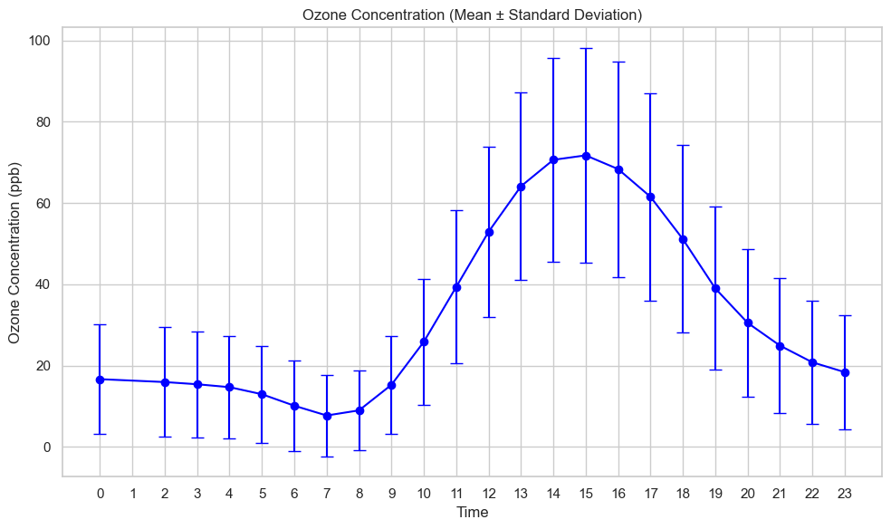

```python
# Group by hour and calculate mean and standard deviation for OZONO across all stations
ozone_stats = df.groupby('hour')['OZONO'].agg(['mean', 'std']).reset_index()

# Display the computed statistics
print(ozone_stats)

# Generate the plot
plt.figure(figsize=(10, 6))
plt.errorbar(ozone_stats['hour'], ozone_stats['mean'], yerr=ozone_stats['std'], fmt='o-', capsize=5, color='blue')
plt.xlabel('Time')
plt.ylabel('Ozone Concentration (ppb)')
plt.title('Ozone Concentration (Mean ± Standard Deviation)')
plt.xticks(range(0, 24))
plt.grid(True)
plt.tight_layout()
plt.show()
```

**Monthly Ozone Concentration Profile (Mean ± Standard Deviation)**

```
    month       mean        std
0       1  23.696502  21.994621
1       2  33.795975  30.158769
2       3  38.143305  29.666558
3       4  43.401985  30.257707
4       5  53.949369  35.373132
5       6  37.305773  24.253291
6       7  26.318921  22.752391
7       8  28.572428  24.906590
8       9  26.347577  24.810201
9      10  26.822683  21.221678
10     11  26.929170  25.838579
11     12  26.365022  25.993852
```

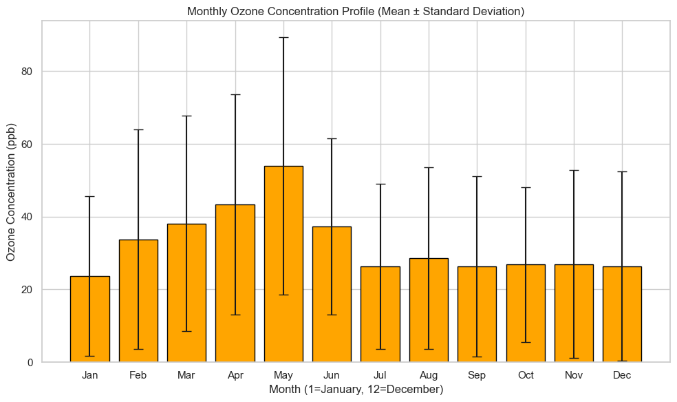

```python
# Group by month and calculate mean and standard deviation for OZONO across all stations
ozone_stats = df.groupby('month')['OZONO'].agg(['mean', 'std']).reset_index()

# Display the computed statistics
print(ozone_stats)

# Generate the bar chart
plt.figure(figsize=(10, 6))
plt.bar(ozone_stats['month'], ozone_stats['mean'], yerr=ozone_stats['std'], capsize=5, color='orange', edgecolor='black')
plt.xlabel('Month (1=January, 12=December)')
plt.ylabel('Ozone Concentration (ppb)')
plt.title('Monthly Ozone Concentration Profile (Mean ± Standard Deviation)')
plt.xticks(range(1, 13), ['Jan', 'Feb', 'Mar', 'Apr', 'May', 'Jun', 'Jul', 'Aug', 'Sep', 'Oct', 'Nov', 'Dec'])
plt.grid(True, axis='y')
plt.tight_layout()
plt.show()
```

**Daily Maximum Ozone Concentration Across All Stations**

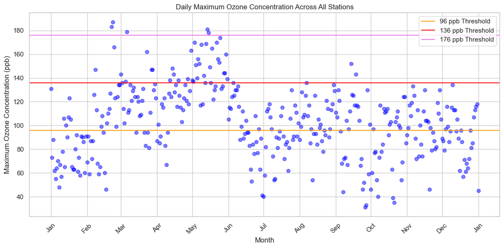

```python
# Group by date and find the maximum OZONO value across all stations
max_ozone = df.groupby('date')['OZONO'].max().reset_index()

# Convert date column to datetime for plotting
max_ozone['date'] = pd.to_datetime(max_ozone['date'])


# Generate the scatter plot
plt.figure(figsize=(12, 6))
plt.scatter(max_ozone['date'], max_ozone['OZONO'], color='blue', alpha=0.5)
plt.axhline(y=96, color='orange', linestyle='-', label='96 ppb Threshold')
plt.axhline(y=136, color='red', linestyle='-', label='136 ppb Threshold')
plt.axhline(y=176, color='violet', linestyle='-', label='176 ppb Threshold')
plt.xlabel('Month')
plt.ylabel('Maximum Ozone Concentration (ppb)')
plt.title('Daily Maximum Ozone Concentration Across All Stations')
plt.gca().xaxis.set_major_locator(MonthLocator())
plt.gca().xaxis.set_major_formatter(DateFormatter('%b'))
plt.grid(True)
plt.legend()
plt.xticks(rotation=45)
plt.tight_layout()
plt.show()
```

**Mapa de Calor Anotado de Ozono Máximo Diario (Promedio por Mes/Día)**

```
Valores mínimos y máximos de OZONO en la tabla pivote:
Min: 31.0, Max: 187.0
```

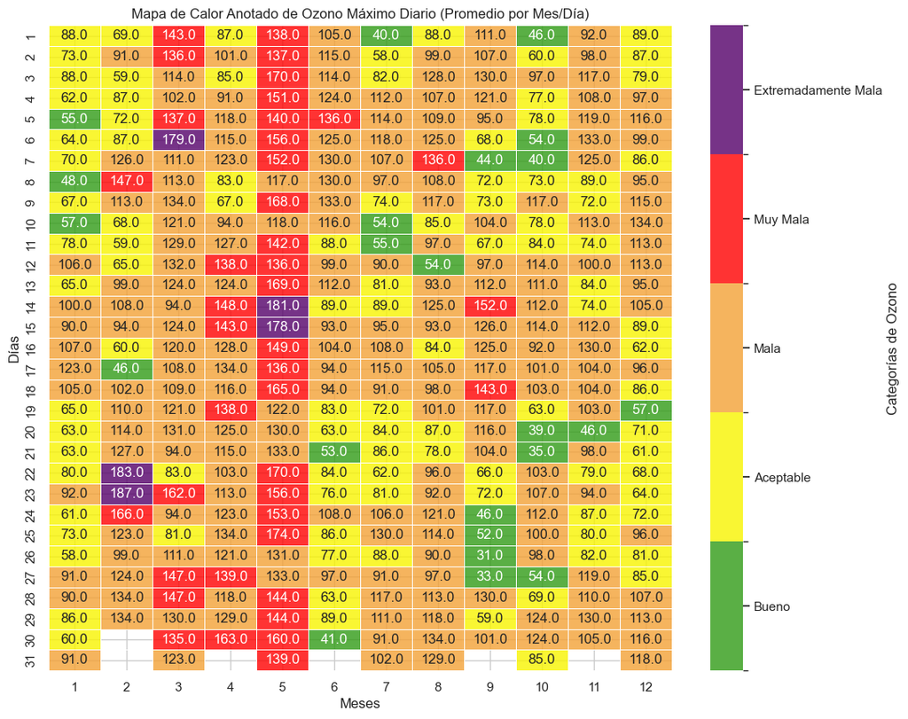

```python
# Calcular el máximo de OZONO por día across todas las estaciones
daily_max = df.groupby('FECHA')['OZONO'].max().reset_index()

# Convertir FECHA a datetime y extraer año, mes y día
daily_max['FECHA'] = pd.to_datetime(daily_max['FECHA'])
daily_max['year'] = daily_max['FECHA'].dt.year
daily_max['month'] = daily_max['FECHA'].dt.month
daily_max['day'] = daily_max['FECHA'].dt.day

# Agrupar por mes y día, calculando el promedio de los máximos diarios
pivot_data = daily_max.groupby(['month', 'day'])['OZONO'].mean().reset_index()

# Crear una tabla pivote completa (1-12 meses, 1-31 días)
pivot = pd.pivot_table(pivot_data, values='OZONO', index='day', columns='month', aggfunc='mean')

# Verificar si la tabla pivote tiene datos válidos
if pivot.empty or pivot.isna().all().all():
    raise ValueError("La tabla pivote está vacía o contiene solo NaN. Verifique que haya datos suficientes.")

# Imprimir estadísticas básicas para depuración
print(f"Valores mínimos y máximos de OZONO en la tabla pivote:\nMin: {pivot.min().min()}, Max: {pivot.max().max()}")

# Definir categorías y colores tipo semáforo con opacidad reducida (alpha=0.7)
categories = ['Bueno', 'Aceptable', 'Mala', 'Muy Mala', 'Extremadamente Mala']
colors = [
    to_rgba("#319B16", 0.8),
    to_rgba("#F8F400", 0.8),
    to_rgba("#F3A136", 0.8),
    to_rgba("#FF0000", 0.8),
    to_rgba("#540069", 0.8)
]
cmap = ListedColormap(colors)

# Definir límites para las categorías
max_ozono = pivot.max().max() if not pivot.isna().all().all() else 175
bounds = [0, 58, 90, 135, 175, max(max_ozono, 176)]
norm = BoundaryNorm(bounds, cmap.N)

# Crear el mapa de calor anotado
fig, ax = plt.subplots(figsize=(12, 10))
sns.heatmap(pivot, annot=True, fmt='.1f', cmap=cmap, norm=norm, ax=ax,
            linewidths=0.5, cbar_kws={'label': 'Categorías de Ozono'},
            mask=pivot.isna())  # Oculta celdas con NaN

# Personalizar la barra de colores
cbar = ax.collections[0].colorbar
centers = [29, 74, 112.5, 155, (175 + bounds[-1]) / 2]
cbar.set_ticks(centers)
cbar.set_ticklabels(categories)

# Etiquetas de ejes
ax.set_xlabel('Meses')
ax.set_ylabel('Días')

# Título
plt.title('Mapa de Calor Anotado de Ozono Máximo Diario (Promedio por Mes/Día)')

# Mostrar el gráfico
plt.show()
```

```python
# Function to create plot for a specific date
def plot_ozone_for_date(month_day, date_label):
    # Filter data for specific date
    filtered_data = df[df['FECHA_HORA'].dt.strftime('%m-%d') == month_day]

    if filtered_data.empty:
        print(f"No data available for {date_label}")
        return

    # Group by station and find the maximum OZONO value
    max_values = filtered_data.groupby('ESTACION')['OZONO'].max().reset_index()
    max_values = max_values.sort_values('OZONO', ascending=False)

    # Create the plot
    plt.figure(figsize=(12, 6))
    bars = plt.bar(range(len(max_values)), max_values['OZONO'], color='lightgreen')

    plt.xlabel('Stations')
    plt.ylabel('Maximum Ozone Concentration (ppb)')
    plt.title(f'Maximum Ozone Concentration by Station - {date_label}')
    plt.xticks(range(len(max_values)), max_values['ESTACION'], rotation=45, ha='right')

    # # Add value labels on bars
    # for i, (bar, value) in enumerate(zip(bars, max_values['OZONO'])):
    #     plt.text(bar.get_x() + bar.get_width()/2, bar.get_height() + 1,
    #              f'{value:.1f}', ha='center', va='bottom', fontsize=9)

    # Add threshold lines
    plt.axhline(y=96, color='orange', linestyle='--', linewidth=2, label='96 ppb Threshold')
    plt.axhline(y=136, color='red', linestyle='--', linewidth=2, label='136 ppb Threshold')
    plt.axhline(y=176, color='violet', linestyle='--', linewidth=2, label='176 ppb Threshold')

    plt.legend()
    plt.grid(True, alpha=0.3)
    plt.tight_layout()
    plt.show()

    return max_values

# Generate plots for both dates
print("Generating plot for May 14th...")
may_14_data = plot_ozone_for_date('05-14', 'May 14th')


# Print summary data
if may_14_data is not None:
    print("\nMay 14th Data:")
    print(may_14_data)
```

[output not shown]

**RESULTADOS**

**Variabilidad Diurna y Estacional del O₃**

El análisis de promedios horarios permite caracterizar la dinámica de las concentraciones de ozono. En términos generales, estas se mantienen bajas durante la noche y en las primeras horas de la mañana, incrementándose progresivamente conforme avanza el día hasta alcanzar su máximo durante las horas de mayor radiación solar —habitualmente entre el mediodía y las primeras horas de la tarde—, debido a la naturaleza fotoquímica de su formación. En el Área Metropolitana del Valle de México (AMVM), los picos de concentración suelen registrarse alrededor de las 15:00 horas. El estudio de promedios mensuales posibilita identificar patrones estacionales. El ozono troposférico tiende a presentar valores más elevados durante los meses cálidos o en la estación seca, cuando la mayor disponibilidad de radiación solar y las temperaturas elevadas favorecen las reacciones fotoquímicas que lo generan. En el contexto del AMVM, se observa un incremento de las concentraciones entre febrero y mayo, seguido de una disminución significativa a partir de junio. Mayo se identifica consistentemente como el mes con las concentraciones más altas de ozono, alcanzando niveles que pueden superar la categoría de riesgo “Extremadamente Alto” según la NOM-172-SEMARNAT-2023. La disminución significativa de junio a diciembre se relaciona con menor radiación solar y aumento de humedad, factores que limitan las reacciones fotoquímicas responsables de la formación de ozono.

**Evaluación de excedencias y visualización de datos**

### **VENTANA DE 8 HORAS**

```python
# Estaciones de interés
estaciones = ['AJU', 'TLI', 'IZT']

# Extraer los datos de ozono para cada estación (eliminar NaN)
datos = {}
for estacion in estaciones:
    ozono_vals = df[df['ESTACION'] == estacion]['OZONO'].dropna()
    datos[estacion] = ozono_vals
    print(f"Estación {estacion}: {len(ozono_vals)} observaciones")

print("\n" + "="*70)
print("📊 PRUEBA MANN-WHITNEY U (Comparaciones por pares)")
print("="*70)

# Lista para guardar resultados
resultados = []

# Comparar todas las combinaciones por pares
from itertools import combinations

for est1, est2 in combinations(estaciones, 2):
    data1 = datos[est1]
    data2 = datos[est2]

    # Aplicar prueba Mann-Whitney U (hipótesis alternativa: 'two-sided')
    stat, p_value = mannwhitneyu(data1, data2, alternative='two-sided')

    # Interpretar
    alpha = 0.05
    significativo = p_value < alpha

    resultado = {
        'Comparación': f"{est1} vs {est2}",
        'Estadístico U': stat,
        'p-valor': p_value,
        'Diferencia significativa': significativo
    }
    resultados.append(resultado)

    print(f"\n🔹 {est1} vs {est2}")
    print(f"   Estadístico U: {stat:.2f}")
    print(f"   p-valor: {p_value:.6f}")
    if significativo:
        print(f"   ✅ Hay diferencia significativa en Ozono entre {est1} y {est2}")
        # Opcional: indicar cuál tiene valores mayores
        med1, med2 = data1.median(), data2.median()
        if med1 > med2:
            print(f"      ➤ {est1} tiene mayor mediana de Ozono ({med1:.2f} vs {med2:.2f})")
        else:
            print(f"      ➤ {est2} tiene mayor mediana de Ozono ({med2:.2f} vs {med1:.2f})")
    else:
        print(f"   ❌ No hay diferencia significativa en Ozono entre {est1} y {est2}")

# Convertir resultados a DataFrame para mejor visualización
print("\n" + "="*70)
print("📋 RESUMEN DE RESULTADOS")
print("="*70)
df_resultados = pd.DataFrame(resultados)
print(df_resultados.to_string(index=False))
```

[output not shown]

**Distribucion de Ozono por tipo de estacion**

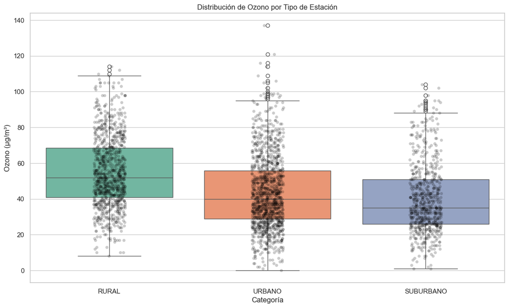

```python
sns.boxplot(data=df, x='CATEGORIA', y='OZONO', hue='CATEGORIA', palette='Set2', legend=False)
sns.stripplot(data=df, x='CATEGORIA', y='OZONO', color='black', alpha=0.2, jitter=True)
plt.title('Distribución de Ozono por Tipo de Estación')
plt.xlabel('Categoría')
plt.ylabel('Ozono (µg/m³)')
plt.show()
```

**Histogramas de concentracion de Ozono por estacion**

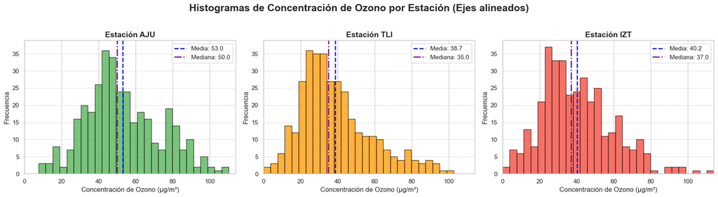

```python
# Configurar estilo visual
sns.set_style("whitegrid")
plt.rcParams['figure.figsize'] = (14, 8)

# Estaciones de interés
estaciones = ['AJU', 'TLI', 'IZT']
df_filtrado = df[df['ESTACION'].isin(estaciones)]

# Calcular rango global de OZONO (para fijar el eje X)
ozono_global = df_filtrado['OZONO'].dropna()
xmin, xmax = ozono_global.min(), ozono_global.max()

# Calcular el máximo de frecuencia (para fijar el eje Y)
max_frecuencia = 0
bins = 30  # mismo número de bins para todos

for estacion in estaciones:
    datos = df_filtrado[df_filtrado['ESTACION'] == estacion]['OZONO'].dropna()
    frecuencias, _ = np.histogram(datos, bins=bins, range=(xmin, xmax))
    max_frecuencia = max(max_frecuencia, frecuencias.max())

# Crear subplots
fig, axes = plt.subplots(1, 3, figsize=(18, 5), sharey=False)
fig.suptitle('Histogramas de Concentración de Ozono por Estación (Ejes alineados)', fontsize=18, fontweight='bold')

colores = ['#4CAF50', '#FF9800', '#F44336']  # Verde, Naranja, Rojo

for i, estacion in enumerate(estaciones):
    datos = df_filtrado[df_filtrado['ESTACION'] == estacion]['OZONO'].dropna()

    # Histograma con rango fijo en X y límite en Y
    n, bins_edges, patches = axes[i].hist(
        datos,
        bins=bins,
        range=(xmin, xmax),
        color=colores[i],
        edgecolor='black',
        alpha=0.75
    )

    axes[i].set_title(f'Estación {estacion}', fontsize=14, fontweight='bold')
    axes[i].set_xlabel('Concentración de Ozono (µg/m³)', fontsize=12)
    axes[i].set_ylabel('Frecuencia', fontsize=12)
    axes[i].set_xlim(xmin, xmax)
    axes[i].set_ylim(0, max_frecuencia * 1.05)  # 5% de margen superior
    axes[i].grid(axis='y', linestyle='--', alpha=0.7)

    # Añadir media y mediana
    media = datos.mean()
    mediana = datos.median()
    axes[i].axvline(media, color='blue', linestyle='--', linewidth=2, label=f'Media: {media:.1f}')
    axes[i].axvline(mediana, color='purple', linestyle='-.', linewidth=2, label=f'Mediana: {mediana:.1f}')
    axes[i].legend()

plt.tight_layout(rect=[0, 0, 1, 0.96])  # Dejar espacio para el título superior
plt.show()
```

**Temperatura vs ozono**

```
================================================================================
📈 REGRESIÓN LINEAL: TEMPERATURA_MEDIA_8H vs OZONO (AJU, CUT, GAM) — Una gráfica
================================================================================

🔹 Estación: AJU
   Pendiente: 3.7344
   Intercepto: -6.3683
   R²: 0.4063
   p-valor: 8.124e-40
   ✅ Relación significativa

🔹 Estación: CUT
   Pendiente: 2.9827
   Intercepto: -27.5673
   R²: 0.4031
   p-valor: 2.282e-35
   ✅ Relación significativa

🔹 Estación: GAM
   Pendiente: 4.7382
   Intercepto: -68.6530
   R²: 0.6292
   p-valor: 6.552e-47
   ✅ Relación significativa
```

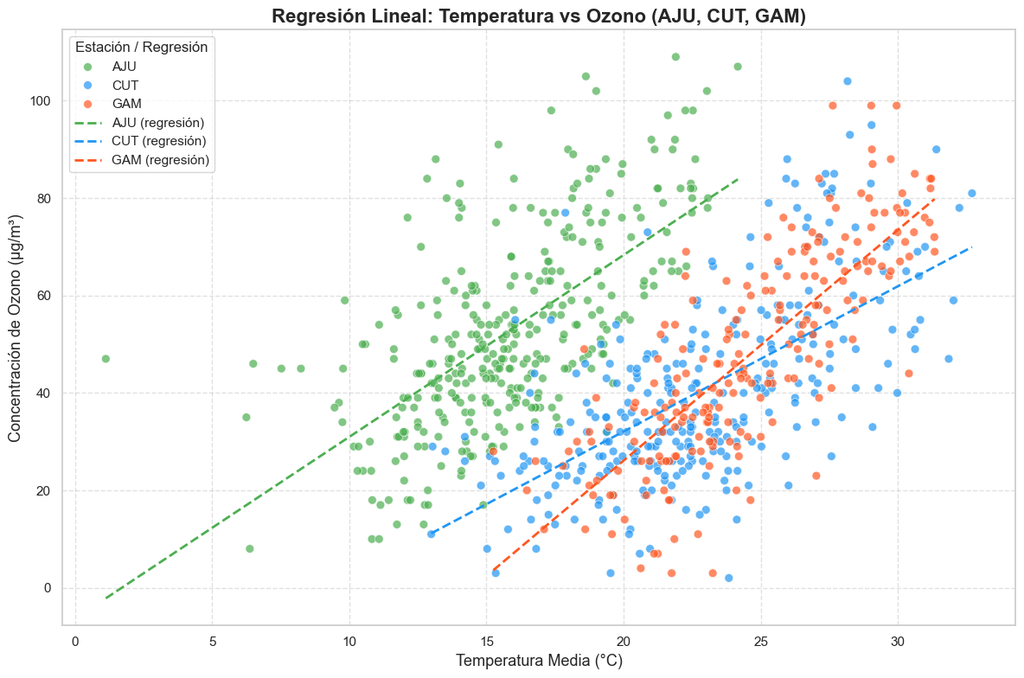

```python
# Configurar estilo
sns.set_theme(style="whitegrid")
plt.figure(figsize=(12, 8))


# ==============================
# GRUPO 1: TEMPERATURA vs OZONO (AJU, CUT, GAM) — EN UNA SOLA GRÁFICA
# ==============================
estaciones_grupo1 = ['AJU', 'CUT', 'GAM']
df_grupo1 = df[df['ESTACION'].isin(estaciones_grupo1)].dropna(subset=['TEMPERATURE_MEDIA_8H', 'OZONO'])

print("="*80)
print("📈 REGRESIÓN LINEAL: TEMPERATURA_MEDIA_8H vs OZONO (AJU, CUT, GAM) — Una gráfica")
print("="*80)

# Paleta de colores para las estaciones
paleta = {'AJU': '#4CAF50', 'CUT': '#2196F3', 'GAM': '#FF5722'}

# Crear scatter plot con regresión por estación
sns.scatterplot(data=df_grupo1, x='TEMPERATURE_MEDIA_8H', y='OZONO', hue='ESTACION', palette=paleta, alpha=0.7, s=50)

# Agregar líneas de regresión manualmente (sin anotaciones en gráfico)
for estacion in estaciones_grupo1:
    datos = df_grupo1[df_grupo1['ESTACION'] == estacion]
    x = datos['TEMPERATURE_MEDIA_8H']
    y = datos['OZONO']

    # Calcular regresión lineal
    slope, intercept, r_value, p_value, std_err = linregress(x, y)
    r_squared = r_value**2

    # Imprimir resultados en consola
    print(f"\n🔹 Estación: {estacion}")
    print(f"   Pendiente: {slope:.4f}")
    print(f"   Intercepto: {intercept:.4f}")
    print(f"   R²: {r_squared:.4f}")
    print(f"   p-valor: {p_value:.3e}")
    if p_value < 0.05:
        print("   ✅ Relación significativa")
    else:
        print("   ❌ Relación no significativa")

    # Dibujar línea de regresión
    x_line = np.linspace(x.min(), x.max(), 100)
    y_line = slope * x_line + intercept
    plt.plot(x_line, y_line, color=paleta[estacion], linestyle='--', linewidth=2, label=f'{estacion} (regresión)')

# Personalizar gráfica
plt.title('Regresión Lineal: Temperatura vs Ozono (AJU, CUT, GAM)', fontsize=16, fontweight='bold')
plt.xlabel('Temperatura Media (°C)', fontsize=13)
plt.ylabel('Concentración de Ozono (µg/m³)', fontsize=13)
plt.legend(title='Estación / Regresión')
plt.grid(True, linestyle='--', alpha=0.6)
plt.tight_layout()
plt.show()
```

**NOX VS Ozono**

```
================================================================================
📈 REGRESIÓN LINEAL: NOX_MEDIA_8H vs OZONO (AJM, TLI, IZT) — Una gráfica
================================================================================

🔹 Estación: AJM
   Pendiente: -0.2474
   Intercepto: 58.5866
   R²: 0.0098
   p-valor: 7.472e-02
   ❌ Relación no significativa

🔹 Estación: TLI
   Pendiente: -0.7265
   Intercepto: 53.0501
   R²: 0.1424
   p-valor: 5.553e-13
   ✅ Relación significativa

🔹 Estación: IZT
   Pendiente: -0.5979
   Intercepto: 56.3080
   R²: 0.1295
   p-valor: 2.043e-12
   ✅ Relación significativa
```

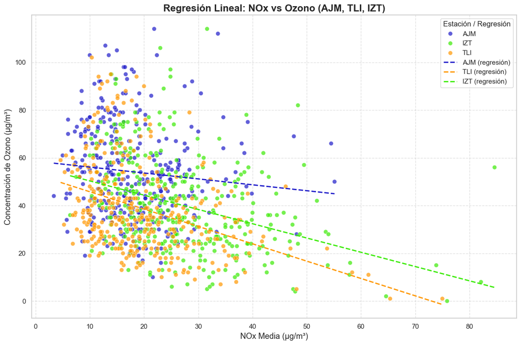

```python
# Configurar estilo
sns.set_theme(style="whitegrid")
plt.figure(figsize=(12, 8))


# ==============================
# GRUPO 2: NOX vs OZONO (AJM, TLI, IZT) — EN UNA SOLA GRÁFICA
# ==============================
estaciones_grupo2 = ['AJM', 'TLI', 'IZT']
df_grupo2 = df[df['ESTACION'].isin(estaciones_grupo2)].dropna(subset=['NOX_MEDIA_8H', 'OZONO'])

print("="*80)
print("📈 REGRESIÓN LINEAL: NOX_MEDIA_8H vs OZONO (AJM, TLI, IZT) — Una gráfica")
print("="*80)

# Paleta de colores para las estaciones
paleta = {'AJM': "#1E1BC9", 'TLI': '#FF9800', 'IZT': "#3BEB05"}  # Morado, Naranja, Rojo

# Crear scatter plot con puntos coloreados por estación
sns.scatterplot(data=df_grupo2, x='NOX_MEDIA_8H', y='OZONO', hue='ESTACION', palette=paleta, alpha=0.7, s=50)

# Agregar líneas de regresión manualmente
for estacion in estaciones_grupo2:
    datos = df_grupo2[df_grupo2['ESTACION'] == estacion]
    x = datos['NOX_MEDIA_8H']
    y = datos['OZONO']

    # Calcular regresión lineal
    slope, intercept, r_value, p_value, std_err = linregress(x, y)
    r_squared = r_value**2

    # Imprimir resultados en consola
    print(f"\n🔹 Estación: {estacion}")
    print(f"   Pendiente: {slope:.4f}")
    print(f"   Intercepto: {intercept:.4f}")
    print(f"   R²: {r_squared:.4f}")
    print(f"   p-valor: {p_value:.3e}")
    if p_value < 0.05:
        print("   ✅ Relación significativa")
    else:
        print("   ❌ Relación no significativa")

    # Dibujar línea de regresión
    x_line = np.linspace(x.min(), x.max(), 100)
    y_line = slope * x_line + intercept
    plt.plot(x_line, y_line, color=paleta[estacion], linestyle='--', linewidth=2, label=f'{estacion} (regresión)')

# Personalizar gráfica
plt.title('Regresión Lineal: NOx vs Ozono (AJM, TLI, IZT)', fontsize=16, fontweight='bold')
plt.xlabel('NOx Media (µg/m³)', fontsize=13)
plt.ylabel('Concentración de Ozono (µg/m³)', fontsize=13)
plt.legend(title='Estación / Regresión')
plt.grid(True, linestyle='--', alpha=0.6)
plt.tight_layout()
plt.show()
```

**Relación entre ozono y Temperatura**

**Relación inversa entre ozono y NOx**

La gráfica (NO vs O₃) confirma que el NO es un precursor y factor clave en la dinámica del ozono, pero su comportamiento varía según el tipo de estación. La línea de regresión azul de la estación rural (AJM) es la que muestra la menor relación inversa (la pendiente más cercana a cero) con los óxidos de nitrógeno (NOx) en comparación con las estaciones urbanas (IZT) y suburbanas (TLI).

El análisis de las concentraciones de ozono troposférico en el Área Metropolitana del Valle de México (AMVM), basado en datos del SIMAT y procesado en Python, permitió caracterizar la variabilidad temporal, estacional y espacial del contaminante, así como su relación con precursores (NOx).

REFERENCIAS BIBLIOGRÁFICAS

1. Agencia de Protección Ambiental de Estados Unidos (EPA). (2023). Technical Air Quality Index (AQI) Information. Recuperado el 17 de septiembre de 2025, de https://www.epa.gov/air-quality-index-aqi/technical-air-quality-index-aqi-information
2. Calderón, M., et al. (2018). Ozone pollution in Mexico City: Trends and meteorological influences. Atmospheric Environment, 189, 1–12. https://doi.org/10.1016/j.atmosenv.2018.06.044
3. SIMAT. (2023). Sistema de Monitoreo Atmosférico de la Ciudad de México. Gobierno de la CDMX. https://www.simat.cdmx.gob.mx/
4. NOAA NCEI. (2023). Global Historical Climatology Network - Daily (GHCN-D). https://www.ncei.noaa.gov/products/land-based-station/global-historical-climatology-network-daily
5. Secretaría de Medio Ambiente y Recursos Naturales (SEMARNAT). (2020). Norma Oficial Mexicana NOM-172-SEMARNAT-2019, Lineamientos para la obtención y validación del Índice de Calidad del Aire y Riesgos a la Salud. Diario Oficial de la Federación.
6. Gobierno de la Ciudad de México. (s. f.). ¿Qué es el Índice AIRE y SALUD? Secretaría del Medio Ambiente (SEDEMA). Recuperado el 17 de septiembre de 2025, de https://www.aire.cdmx.gob.mx/#!/indice-aire-y-salud